# Exploratory Data Analysis

Ahsan Iftikhar

2022-06-10

## Objective

Using the data, achieve the following objectives in Pakistan.

1. Identify the most popular cars in Pakistan.
2. Identify the cars most commonly sold in Pakistan across different brands
3. Which is better in terms of it’s resale value.
4. Predict the cars for the cases, which has missing data for the cars.

Loading the required packages

```r
library(tidyverse)
library(treemapify)
library(paletteer)
library(ggtext)
library(showtext)
library(gt)

font_add_google(name = "Lora", family = "title_font")
font_add_google(name = "Roboto", family = "body_font")
showtext_auto()
```

## Loading data

```r
olx_car_data <- read_csv("data/OLX_Car_Data_CSV.csv")
```

# Data Book

Sample data contains vehicles registered for the year 1915 to 2020. The sample comprises of 24973 rows and 9 variables.

Data book

Data type and description of variables in the dataset

| Variable | Data type | Description |
| --- | --- | --- |
| Brand | character | Brand name of the car in sample dataset |
| Condition | character | Whether the car is new or used |
| Fuel | character | Fuel types used to operate the car |
| KMs Driven | double | Kilometers the vehicle is driven |
| Model | character | Vehicle model from the manufacturer |
| Price | double | Price is PKR |
| Registered City | character | City of Registration |
| Transaction Type | character | Cash transaction or leased vehicle |
| Year | double | Year of registration |

## Feature engineering

Listing all the different types, so it can be grouped by country/region of origin. Country of manufacturing, have different price points and consequently market is segmented based on it. In addition, different brand manufacturers cater to high end customers based on the prestige, # and brand value. Thus to make meaningful comparison it is important to add variables and thus compare like groups.

```r
unique(olx_car_data$Brand)
```

```
##  [1] "Toyota"             "Suzuki"             "Honda"
##  [4] "Daihatsu"           "Mitsubishi"         "KIA"
##  [7] "Other Brands"       "Nissan"             "BMW"
## [10] "Mazda"              "Chevrolet"          "Daewoo"
## [13] "Hyundai"            "FAW"                "Mercedes"
## [16] "Classic & Antiques" "Lexus"              "Audi"
## [19] "Range Rover"        NA                   "Changan"
## [22] "Porsche"            "Subaru"             "Land Rover"
```

Creating a new variable to determine the country of origin/manufacturing of the difference vehicles contains in the same dataset.

```r
european <- c("Range Rover", "Land Rover", "Porsche", "Audi",
              "BMW", "Mercedes")
japanese <- c("Toyota", "Honda", "Mitsubishi", "Lexus", "Subaru", "Suzuki",
              "Daihatsu", "Daihatsu",  "Nissan" , "Mazda")
korean = c("Hyundai" , "KIA", "Daewoo")
chinese = c("FAW", "Changan")
american = c("Chevrolet")

olx_car_data <- olx_car_data %>%
  mutate(origin_country = case_when(
    Brand %in% european ~ "Europe",
    Brand %in% japanese ~ "Japan",
    Brand %in% korean ~ "Korea",
    Brand %in% chinese ~ "China",
    Brand %in% american ~ "American",
    TRUE ~ as.character(Brand))
  )


# Popularity of used cars in Pakistan
# Popularity of the car is determined based on its proportionate
# representation, in the sample data

olx_car_data_by_org <- olx_car_data %>%
  group_by(origin_country) %>%
  count() %>%
  drop_na() %>%
  arrange(desc(n)) %>%
  ungroup()


olx_car_data_by_org_gt <- olx_car_data_by_org %>%
  gt() %>%
  gt::tab_header(
    title = "Number of vehicles by country of origin",
    subtitle = "Japanese vehicles seem to be the most popular"
  ) %>%
  gt::cols_label(
    origin_country = "Origin Country",
    n = "# of Vehicle"
  ) %>%
  gt::fmt_number(
    columns = c("n"),
    use_seps = TRUE,
    decimals = 0
  )

olx_car_data_by_org_gt
```

Number of vehicles by country of origin

Japanese vehicles seem to be the most popular

| Origin Country | # of Vehicle |
| --- | --- |
| Japan | 21,875 |
| Korea | 473 |
| Other Brands | 188 |
| Europe | 151 |
| China | 89 |
| American | 47 |
| Classic & Antiques | 13 |

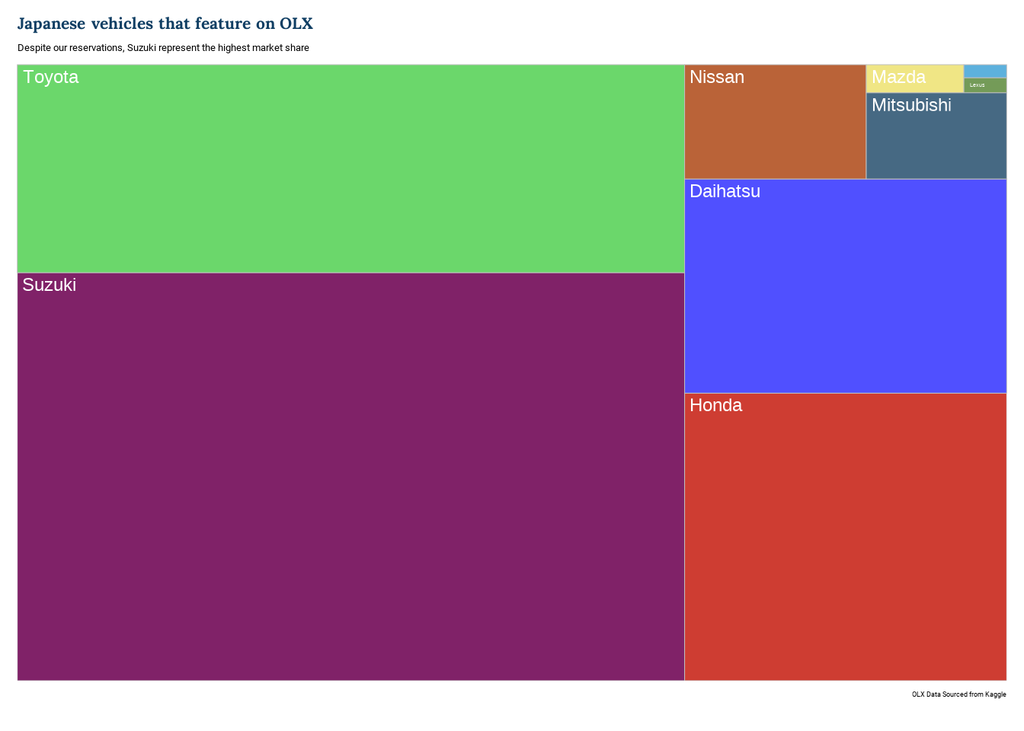

```r
brnd_by_origin <- olx_car_data %>%
  group_by(origin_country, `Brand`) %>%
  count() %>%
  arrange(desc(n)) %>%
  drop_na() %>%
  ungroup()

ggplot(data = filter(brnd_by_origin, origin_country == "Japan"),
       mapping = aes(area = n, label = Brand, fill = Brand)
) +
  geom_treemap() +
  geom_treemap_text(colour = "white", reflow = TRUE) +
  scale_fill_paletteer_d(`"ggsci::default_igv"`) +
  labs(
    title = "**Japanese vehicles that feature on OLX**",
    subtitle = "Despite our reservations, Suzuki represent the highest market share",
    caption = "OLX Data Sourced from Kaggle \n "
  ) +
  theme_minimal() +
  theme(
    legend.position = "none",
    plot.caption = element_text(size = 7),
    text = element_text(family = "body_font", size = 10),
    plot.title = element_markdown(family = "title_font", size = 16,
                                  color = "#0f3e63"),
    plot.margin = margin(3, 3, 3, 3, "mm")
  )
```